# Chronic Wasting Disease in Wisconsin Deer

JVA

2019-12-24

Do you deer hunt in Wisconsin? Have you had your deer tested for chronic wasting disease? I recently learned the results of the test on my deer and was curious about the results statewide.

# Bringing in the data

The county data are available online at [dnr.wi.gov](https://dnr.wi.gov/wmcwd/Summary/County). I used [SelectorGadget](https://cran.r-project.org/web/packages/rvest/vignettes/selectorgadget.html) to identify the columns of data I wanted from each page and the [rvest](https://blog.rstudio.com/2014/11/24/rvest-easy-web-scraping-with-r/) package of [R](https://www.r-project.org/) to do the extraction, looping through the pages with different years of data. You can see the code that I used [here](https://github.com/rbind/jvadams/blob/master/content/post/2019-12-24-chronic-wasting-disease-in-wisconsin-deer.Rmd).

In preparation for mapping the results, I also downloaded state and county mapping data for Wisconsin from the [ggplot2](https://ggplot2.tidyverse.org/) package.

# Summarizing the data

Then I summarized the test data, determining the first year that CWD was detected in each county and the percentage of positive results over all tests during 1999-2019 and just during 2019.

Since 1999, **28** of 72 Wisconsin counties have tested positive for CWD, including **2** counties that tested positive for the first time in 2019: **Sheboygan, Dunn**.

|  | County | First.Detected | Analyzed.Total | Positive.Total | Pos.pct.Total | Analyzed.2019 | Positive.2019 | Pos.pct.2019 |
| --- | --- | --- | --- | --- | --- | --- | --- | --- |
| 1 | Iowa | 2002 | 48603 | 3028 | 6.23006810279201 | 1352 | 367 | 27.1449704142012 |
| 2 | Sauk | 2002 | 18284 | 948 | 5.18486108072632 | 917 | 244 | 26.608505997819 |
| 3 | Richland | 2002 | 13994 | 673 | 4.80920394454766 | 1351 | 230 | 17.0244263508512 |
| 4 | Dane | 2000 | 30215 | 991 | 3.27982790004964 | 998 | 142 | 14.2284569138277 |
| 5 | Lafayette | 2004 | 2983 | 81 | 2.7153871940999 | 194 | 25 | 12.8865979381443 |
| 6 | Columbia | 2003 | 6323 | 147 | 2.32484580104381 | 555 | 60 | 10.8108108108108 |
| 7 | Grant | 2006 | 6056 | 130 | 2.14663143989432 | 642 | 57 | 8.8785046728972 |
| 8 | Rock | 2003 | 8439 | 166 | 1.96705770825927 | 126 | 15 | 11.9047619047619 |
| 9 | Green | 2003 | 3458 | 62 | 1.79294389820706 | 144 | 23 | 15.9722222222222 |
| 10 | Walworth | 2002 | 7029 | 87 | 1.23772940674349 | 98 | 9 | 9.18367346938776 |

[output cut: 62 more lines]

# Mapping the data

I used the data to create a county map showing the percentage of positive results in 2019, the counties that have never tested positive for CWD, and the first year of detection.

Then I created a whole series of maps, one for each year of testing, to see how the counties with positive detections have expanded over time.

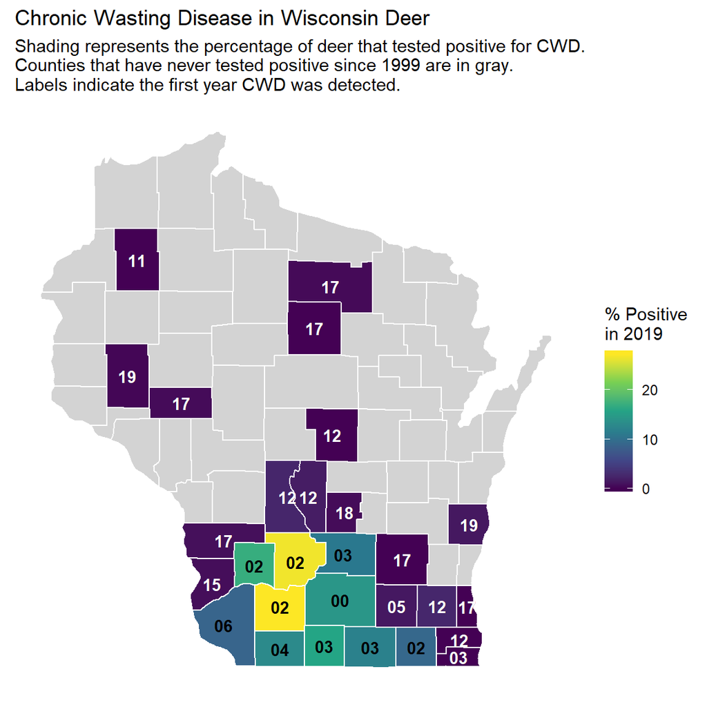

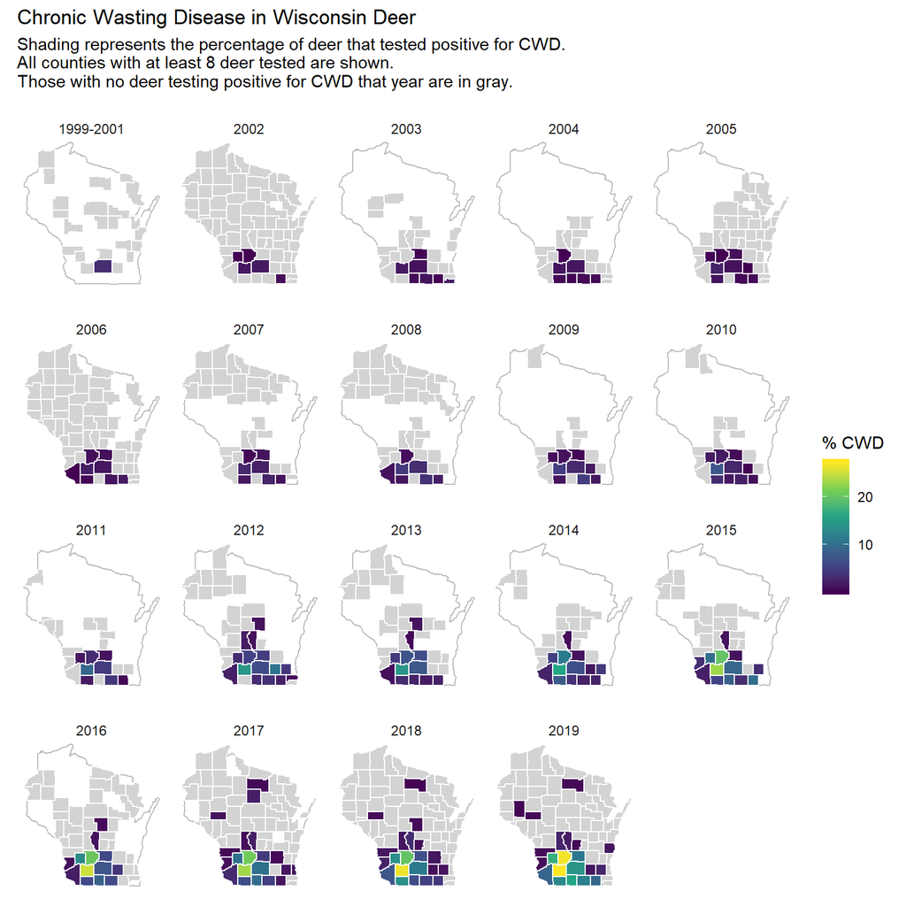

# Plotting the data

Finally, to see the progression of the infection in the deer population over time, I plotted the percentage of positive results for every county that ever had a positive test. I only show percentages for years with at least 8 deer tested in each county. (*The combined data from 1999-2001 is plotted at 2000.*)

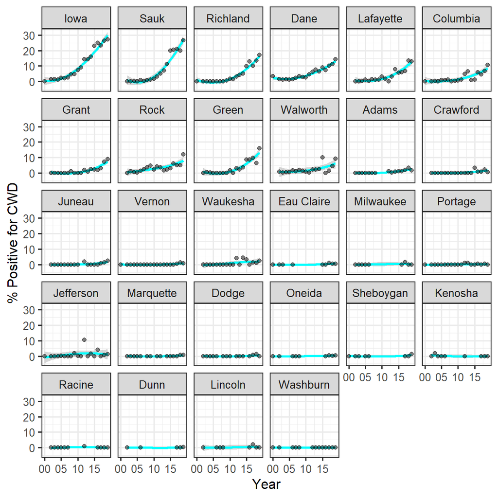